# Practical: Smoking-Attributable IHD Deaths in England, 2012–2023

- Show All Code
- Hide All Code
- View Source

Author

Belen Zapata-Diomedi

# 1 Learning objectives:

This practical teaches you to:

- Calculate Population Impact Fractions (PIF) for binary exposures
- Apply PIFs to estimate attributable disease burden
- Compare observed vs counterfactual scenarios

# 2 Introduction

This practical has two questions:

> **Question 1.** What is the burden of smoking-attributable IHD mortality for males and females aged 50–59 in England, from 2012 to 2023?

> **Question 2.** How many IHD deaths could have been prevented under a scenario of accelerated smoking decline in 2023?

You will use the **Population Impact Fraction (PIF)** formula for a binary exposure (smoker vs non-smoker):

$$PIF = \frac{\sum_i p_i RR_i \;-\; \sum_i p_i^* RR_i}{\sum_i p_i RR_i}$$

Where: - $p_i$ = observed prevalence of exposure category $i$ - $p_i^*$ = counterfactual prevalence (no exposure) - $RR_i$ = relative risk for exposure category $i$

# 3 Data

## 3.1 Smoking prevalence

Cigarette smokers (%) in 50–59 year olds, England.  
Source: ONS Opinions and Lifestyle Survey, 2024.

```r
smoking <- data.frame(
  year       = 2012:2023,
  prev_men   = c(21.9, 19.2, 18.4, 17.1, 15.9, 19.1, 14.7, 19.7, 16.3, 15.9, 17.7, 15.4),
  prev_women = c(17.4, 18.0, 17.3, 15.2, 13.2, 14.9, 15.9, 14.0, 15.6, 13.3, 12.2, 12.6)
)

smoking$p_men   <- smoking$prev_men   / 100
smoking$p_women <- smoking$prev_women / 100

smoking[, c("year", "prev_men", "prev_women")]
```

| year | prev_men | prev_women |
| --- | --- | --- |
| 2012 | 21.9 | 17.4 |
| 2013 | 19.2 | 18.0 |
| 2014 | 18.4 | 17.3 |
| 2015 | 17.1 | 15.2 |
| 2016 | 15.9 | 13.2 |
| 2017 | 19.1 | 14.9 |
| 2018 | 14.7 | 15.9 |
| 2019 | 19.7 | 14.0 |
| 2020 | 16.3 | 15.6 |
| 2021 | 15.9 | 13.3 |

[output cut: 2 more lines]

## 3.2 IHD deaths

IHD deaths, England, ages 50–59 (50–54 + 55–59 summed), by sex.  
Source: GBD 2023 Results Tool (IHME).

```r
ihd <- data.frame(
  year         = 2012:2023,
  deaths_men   = c(2884, 2914, 2855, 2915, 2948, 3033, 3131, 3173, 3477, 3568, 3632, 3882),
  deaths_women = c( 683,  713,  694,  724,  731,  740,  761,  774,  814,  853,  900,  959)
)

ihd
```

| year | deaths_men | deaths_women |
| --- | --- | --- |
| 2012 | 2884 | 683 |
| 2013 | 2914 | 713 |
| 2014 | 2855 | 694 |
| 2015 | 2915 | 724 |
| 2016 | 2948 | 731 |
| 2017 | 3033 | 740 |
| 2018 | 3131 | 761 |
| 2019 | 3173 | 774 |
| 2020 | 3477 | 814 |
| 2021 | 3568 | 853 |

[output cut: 2 more lines]

## 3.3 Relative risks

```r
RR_men   <- 3.04
RR_women <- 3.78

cat("Relative Risks (smoker vs non-smoker):\n")
```

```
Relative Risks (smoker vs non-smoker):
```

```r
cat("  RR for men:   ", RR_men, "\n")
```

```
  RR for men:    3.04
```

```r
cat("  RR for women: ", RR_women, "\n")
```

```
  RR for women:  3.78
```

# 4 Question 1 — Burden of smoking-attributable IHD mortality

## 4.1 Step 1: Calculate the PIF for each year

The PIF formula for binary exposure is:

$$PIF = \frac{p_{smoker} \times RR_{smoker} + p_{non-smoker} \times RR_{non-smoker} - p^*_{smoker} \times RR_{smoker} - p^*_{non-smoker} \times RR_{non-smoker}}{p_{smoker} \times RR_{smoker} + p_{non-smoker} \times RR_{non-smoker}}$$

In R code:

```r
# p_star is the counterfactual: no one smokes
p_star <- c(0, 1)  # p_smoker = 0, p_non-smoker = 1

# PIF = (sum(p × RR) - sum(p_star × RR)) / sum(p × RR)
PIF <- (sum(p * RR) - sum(p_star * RR)) / sum(p * RR)
```

Run the code below to calculate PIFs for all years:

```r
p_star <- c(0, 1) # Represents counterfactual with 0% smoking and 100% not smoking

results <- data.frame(
  year       = 2012:2023,
  PIF_men    = NA_real_,
  PIF_women  = NA_real_,
  attr_men   = NA_real_,
  attr_women = NA_real_
)

for (i in 1:nrow(results)) {

  p_men_obs   <- c(smoking$p_men[i],   1 - smoking$p_men[i])
  p_women_obs <- c(smoking$p_women[i], 1 - smoking$p_women[i])

  RR_men_vec   <- c(RR_men,   1)
  RR_women_vec <- c(RR_women, 1)

  results$PIF_men[i]   <- (sum(p_men_obs * RR_men_vec) - sum(p_star * RR_men_vec)) / sum(p_men_obs * RR_men_vec)
  results$PIF_women[i] <- (sum(p_women_obs * RR_women_vec) - sum(p_star * RR_women_vec)) / sum(p_women_obs * RR_women_vec)

  results$attr_men[i]   <- results$PIF_men[i]   * ihd$deaths_men[i]
  results$attr_women[i] <- results$PIF_women[i] * ihd$deaths_women[i]
}

results$PIF_men    <- round(results$PIF_men   * 100, 1)
results$PIF_women  <- round(results$PIF_women * 100, 1)
results$attr_men   <- round(results$attr_men)
results$attr_women <- round(results$attr_women)
results$attr_total <- results$attr_men + results$attr_women

results
```

| year | PIF_men | PIF_women | attr_men | attr_women | attr_total |
| --- | --- | --- | --- | --- | --- |
| 2012 | 30.9 | 32.6 | 891 | 223 | 1114 |
| 2013 | 28.1 | 33.4 | 820 | 238 | 1058 |
| 2014 | 27.3 | 32.5 | 779 | 225 | 1004 |
| 2015 | 25.9 | 29.7 | 754 | 215 | 969 |
| 2016 | 24.5 | 26.8 | 722 | 196 | 918 |
| 2017 | 28.0 | 29.3 | 850 | 217 | 1067 |
| 2018 | 23.1 | 30.7 | 722 | 233 | 955 |
| 2019 | 28.7 | 28.0 | 910 | 217 | 1127 |
| 2020 | 25.0 | 30.2 | 868 | 246 | 1114 |
| 2021 | 24.5 | 27.0 | 874 | 230 | 1104 |

[output cut: 2 more lines]

**Quick Quiz**

### 4.1.1 Question 1.1: PIF for Men in 2023

Based on the results table above, what is the PIF (percentage) for **men** in 2023?

[interactive chart not shown]

### 4.1.2 Question 1.2: Total Attributable Deaths in 2023

How many **total** attributable IHD deaths (men + women) were there in 2023?

[interactive chart not shown]

## 4.2 Step 2: Plot attributable deaths over time

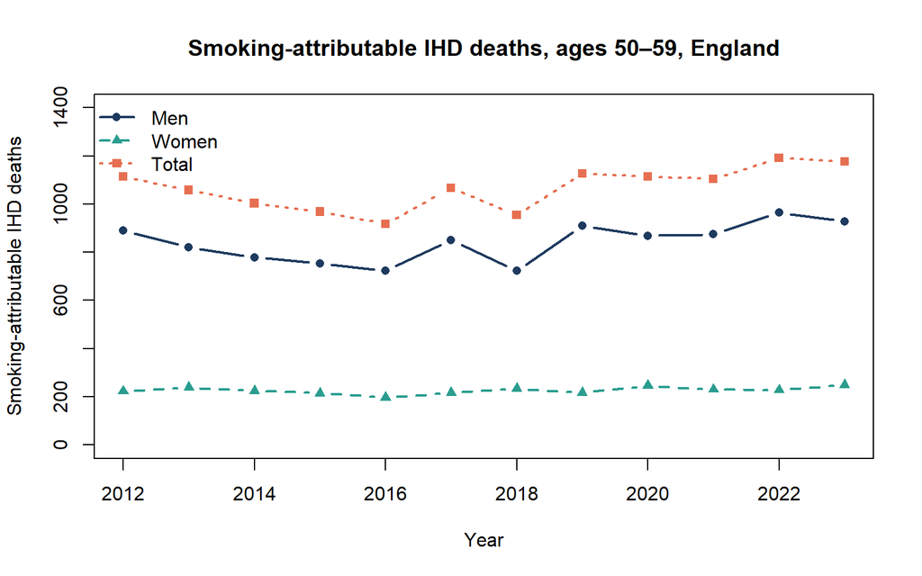

```r
plot(results$year, results$attr_men,
     type = "b", pch = 16, lwd = 2, col = "#1E3A5F",
     ylim = c(0, 1400),
     xlab = "Year",
     ylab = "Smoking-attributable IHD deaths",
     main = "Smoking-attributable IHD deaths, ages 50–59, England")

lines(results$year, results$attr_women,
      type = "b", pch = 17, lwd = 2, lty = 2, col = "#2A9D8F")

lines(results$year, results$attr_total,
      type = "b", pch = 15, lwd = 2, lty = 3, col = "#E76F51")

legend("topleft",
       legend = c("Men", "Women", "Total"),
       col    = c("#1E3A5F", "#2A9D8F", "#E76F51"),
       lwd = 2, lty = c(1, 2, 3), pch = c(16, 17, 15), bty = "n")
```

**Quick Quiz**

### 4.2.1 Question 1.3: Trend Observation

Looking at the plot, what happened to total attributable IHD deaths between 2012 and 2023?

[interactive chart not shown]

> **Q1.1** Smoking prevalence fell between 2012 and 2023 for both sexes. Yet total attributable IHD deaths increased. Explain why (based on the data in this practical).

> **Q1.2** Women have a higher RR (3.78) than men (3.04), yet fewer attributable deaths in every year. What drives this difference?

> **Q1.3** Calculate the cumulative total of attributable IHD deaths across all 12 years. What does this figure represent, and what assumptions does it rest on?

# 5 Question 2 — Prevented deaths under accelerated decline: scenario analysis

## 5.1 The scenario

Smoking prevalence in England has declined since 2012, but what if it had declined *twice as fast*? The scenario sets the **counterfactual 2023 prevalence** to half the **observed 2012 prevalence**:

|  | Observed 2012 | Observed 2023 | **Scenario 2023** |
| --- | --- | --- | --- |
| Men | 21.9% | 15.4% | **10.95%** |
| Women | 17.4% | 12.6% | **8.70%** |

In the PIF formula: $p$ remains the *observed 2023 distribution*; $p^*$ becomes the *scenario distribution*. The PIF then measures the fraction of deaths that would have been prevented in 2023 at a lower prevalence of smoking.

## 5.2 Step 3: Calculate prevented deaths for 2023

Run the code below to calculate deaths prevented under the accelerated decline scenario:

```r
p_men_2023   <- smoking$p_men[smoking$year   == 2023]
p_women_2023 <- smoking$p_women[smoking$year == 2023]

p_men_cf   <- smoking$p_men[smoking$year   == 2012] / 2
p_women_cf <- smoking$p_women[smoking$year == 2012] / 2

deaths_men_2023   <- ihd$deaths_men[ihd$year   == 2023]
deaths_women_2023 <- ihd$deaths_women[ihd$year == 2023]

p_obs_men   <- c(p_men_2023,   1 - p_men_2023)
p_obs_women <- c(p_women_2023, 1 - p_women_2023)

p_cf_men   <- c(p_men_cf,   1 - p_men_cf)
p_cf_women <- c(p_women_cf, 1 - p_women_cf)

RR_men_vec   <- c(RR_men,   1)
RR_women_vec <- c(RR_women, 1)

PIF_men_scenario   <- (sum(p_obs_men * RR_men_vec) - sum(p_cf_men * RR_men_vec)) / sum(p_obs_men * RR_men_vec)
PIF_women_scenario <- (sum(p_obs_women * RR_women_vec) - sum(p_cf_women * RR_women_vec)) / sum(p_obs_women * RR_women_vec)

attr_men_scenario   <- round(PIF_men_scenario   * deaths_men_2023)
attr_women_scenario <- round(PIF_women_scenario * deaths_women_2023)

attr_men_2023   <- results$attr_men[results$year   == 2023]
attr_women_2023 <- results$attr_women[results$year == 2023]

prevented_men   <- attr_men_2023   - attr_men_scenario
prevented_women <- attr_women_2023 - attr_women_scenario

cat("--- 2023 results ---\n")
```

```
--- 2023 results ---
```

```r
cat("Attributable deaths (observed prevalence) — Men:", attr_men_2023,     " Women:", attr_women_2023,     "\n")
```

```
Attributable deaths (observed prevalence) — Men: 928  Women: 249
```

```r
cat("Attributable deaths (scenario prevalence) — Men:", attr_men_scenario, " Women:", attr_women_scenario, "\n")
```

```
Attributable deaths (scenario prevalence) — Men: 268  Women: 77
```

```r
cat("Deaths prevented                            — Men:", prevented_men,       " Women:", prevented_women,       "\n")
```

```
Deaths prevented                            — Men: 660  Women: 172
```

**Quick Quiz**

### 5.2.1 Question 2.1: Total Deaths Prevented

Under the accelerated decline scenario, how many **total** IHD deaths were prevented in 2023?

[interactive chart not shown]

### 5.2.2 Question 2.2: PIF Interpretation

A **higher PIF** means:

[interactive chart not shown]

## 5.3 Step 4: Plot observed vs scenario

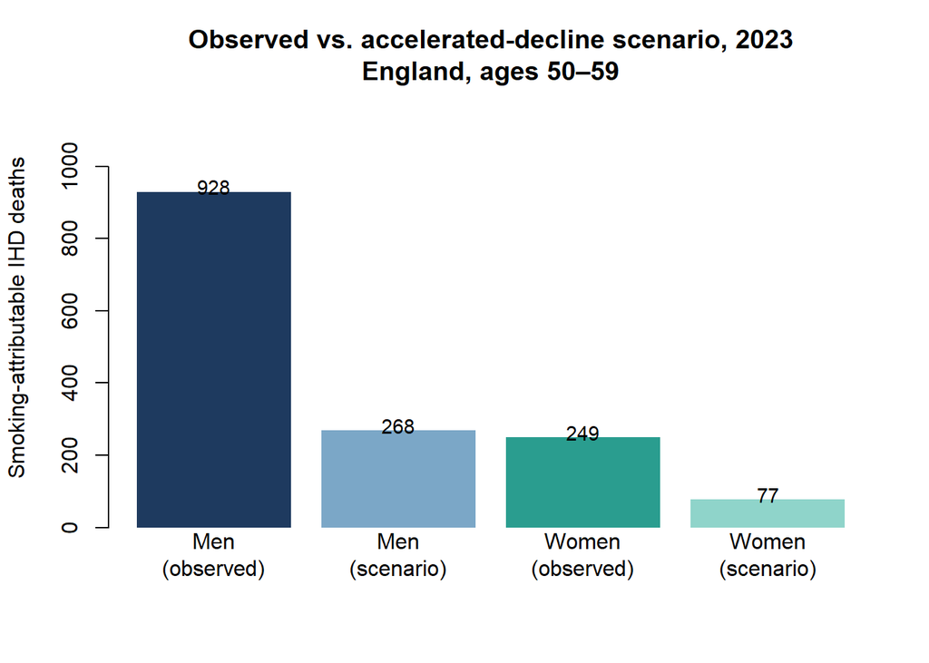

```r
heights <- c(attr_men_2023, attr_men_scenario, attr_women_2023, attr_women_scenario)
cols    <- c("#1E3A5F", "#7BA7C7", "#2A9D8F", "#8FD4CA")
labels  <- c("Men\n(observed)", "Men\n(scenario)", "Women\n(observed)", "Women\n(scenario)")

bp <- barplot(heights,
              names.arg = labels,
              col = cols, border = NA,
              ylab = "Smoking-attributable IHD deaths",
              main = "Observed vs. accelerated-decline scenario, 2023\nEngland, ages 50–59",
              ylim = c(0, max(heights) * 1.25))

text(x = bp, y = heights + 15, labels = heights, cex = 0.9)
```

> **Q2.1** How many IHD deaths would have been prevented in 2023 if smoking had declined twice as fast since 2012? Express this as a percentage of total IHD deaths in this age group in 2023.

> **Q2.2** In the scenario, $p^*$ is set to the counterfactual prevalence. Those who “stop smoking” under the scenario are treated as equivalent to non-smokers (RR = 1). Is this realistic? In which direction does it bias the prevented-deaths estimate?

> **Q2.3** Name one other factor that changed between 2012 and 2023 that this analysis does not account for.

# 6 Summary

**Key Concepts**

### 6.0.1 Population Impact Fraction (PIF)

The fraction of disease that could be prevented if the exposure were eliminated.

### 6.0.2 Binary Exposure

Exposure has two categories (e.g., smoker/non-smoker). The PIF formula compares observed exposure distribution to a counterfactual (e.g., no exposure).

### 6.0.3 Attributable Deaths

Deaths attributable to the exposure = PIF × total deaths

### 6.0.4 Counterfactual

The hypothetical scenario with reduced or eliminated exposure. In Question 2, this is “half the 2012 smoking prevalence.”

# 7 References

1. Office for National Statistics. *Adult Smoking Habits in England, 2024.* Newport: ONS; 2025.
2. GBD 2023 Causes of Death Collaborators. *Global Burden of Disease Study 2023.* Seattle: IHME; 2024.
3. Ezzati M, Lopez AD, Rodgers A, Vander Hoorn S, Murray CJL. Selected major risk factors and global and regional burden of disease. *Lancet.* 2002;360(9343):1347–1360.